# Histograms And Density Plots

# Goal

This notebook shows how to visualize the distribution of one continuous variable.

We focus on center, spread, shape, and unusual values.

A distribution is the collection of observed positions along a measurement scale. The summaries and plots in this notebook are different ways to understand those positions.

# Analytic Questions

We will use a simplified NHANES teaching file to ask:

- What does the distribution of adult systolic blood pressure look like?
- Which summaries describe center and spread?
- How does the bin width change a histogram?
- What does a density plot emphasize differently from a histogram?

# Load Data

```r
nhanes_path <- "data/real/nhanes_2021_2023_analysis.csv"

nhanes <- read_csv(nhanes_path, show_col_types = FALSE)

nhanes |>
  glimpse()
```

```
Rows: 11,933
Columns: 57
$ respondent_id                 <dbl> 130378, 130379, 130380, 130381, 130382, …
$ release_cycle                 <dbl> 12, 12, 12, 12, 12, 12, 12, 12, 12, 12, …
$ interview_exam_status         <chr> "interviewed_and_examined", "interviewed…
$ gender                        <chr> "male", "male", "female", "female", "mal…
$ age_years                     <dbl> 43, 66, 44, 5, 2, 3, 43, 65, 34, 68, 27,…
$ age_months_screening_0_to_24  <dbl> NA, NA, NA, NA, NA, NA, NA, NA, NA, NA, …
$ age_group                     <chr> "30-44", "65-79", "30-44", "0-17", "0-17…
$ race_ethnicity                <chr> "Non-Hispanic Asian", "Non-Hispanic Whit…
$ exam_period                   <chr> "May-October", "May-October", "November-…
$ born_in_us                    <chr> "no", "yes", "no", "yes", "yes", "yes", …
$ years_in_us_category          <chr> "20 years or more", NA, "20 years or mor…
$ education_adults_20_plus      <chr> "College graduate or above", "College gr…
$ marital_status_adults_20_plus <chr> "Married/living with partner", "Married/…
```

[output cut: 44 more lines]

Each row is one participant in the joined NHANES teaching file.

NHANES is a complex survey. In this course, these are exploratory sample visualizations, not national estimates.

# Prepare Adult Blood Pressure Data

Use `filter()` to keep the observations that match the question: adults with a non-missing blood pressure value.

```r
adult_bp <- nhanes |>
  filter(
    age_years >= 18,
    !is.na(systolic_mean)
  )

adult_bp |>
  select(respondent_id, age_years, gender, age_group, systolic_mean) |>
  head()
```

```
# A tibble: 6 × 5
  respondent_id age_years gender age_group systolic_mean
          <dbl>     <dbl> <chr>  <chr>             <dbl>
1        130378        43 male   30-44              133.
2        130379        66 male   65-79              117
3        130380        44 female 30-44              109
4        130386        34 male   30-44              115
5        130387        68 female 65-79              141.
6        130388        27 female 18-29              129
```

# Summarize Before Plotting

Summary statistics are aggregations. They reduce many participant values to a few numbers.

```r
adult_bp_summary <- adult_bp |>
  summarize(
    n = n(),
    mean_systolic = mean(systolic_mean),
    median_systolic = median(systolic_mean),
    min_systolic = min(systolic_mean),
    max_systolic = max(systolic_mean),
    iqr_systolic = IQR(systolic_mean),
    sd_systolic = sd(systolic_mean)
  )

adult_bp_summary
```

```
# A tibble: 1 × 7
      n mean_systolic median_systolic min_systolic max_systolic iqr_systolic
  <int>         <dbl>           <dbl>        <dbl>        <dbl>        <dbl>
1  6123          122.             120           70         232.         21.7
# ℹ 1 more variable: sd_systolic <dbl>
```

The mean and median describe center. The range, IQR, and standard deviation describe spread. The plot will show shape and unusual values that these summaries compress.

This is the main EDA habit: summarize to get oriented, then plot to see what the summaries hide.

# First Histogram

Start with the data and x-axis mapping.

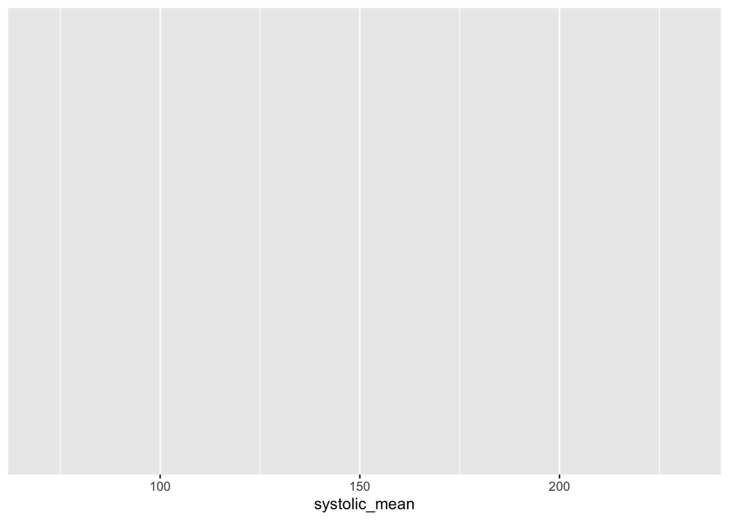

```r
p1 <- ggplot(
  adult_bp,
  aes(x = systolic_mean)
)

p1
```

Add a histogram.

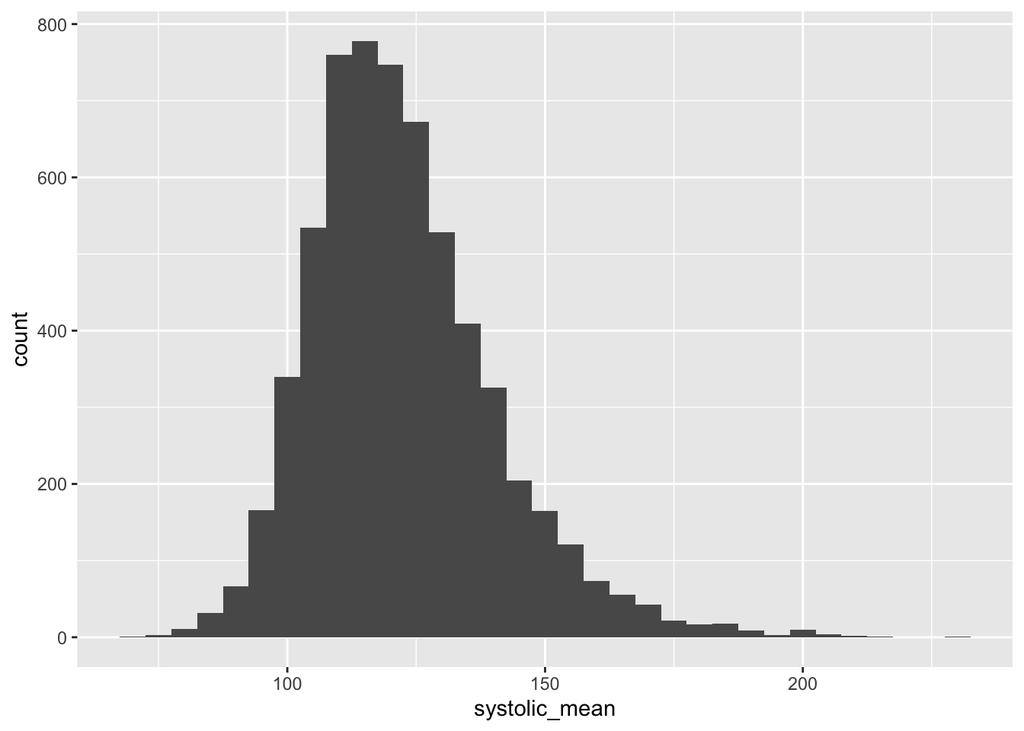

```r
p2 <- p1 +
  geom_histogram(binwidth = 5)

p2
```

Add labels and a theme.

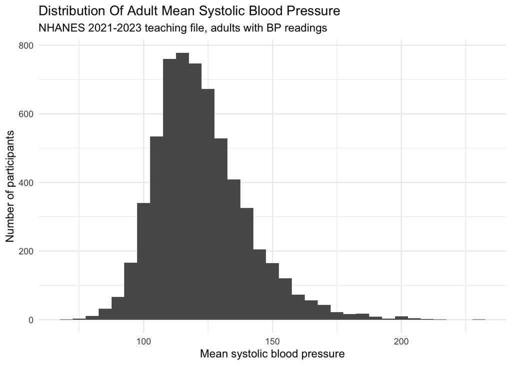

```r
p3 <- p2 +
  labs(
    title = "Distribution Of Adult Mean Systolic Blood Pressure",
    subtitle = "NHANES 2021-2023 teaching file, adults with BP readings",
    x = "Mean systolic blood pressure",
    y = "Number of participants"
  ) +
  theme_minimal()

p3
```

Interpretation: the distribution is centered a little above 120 mmHg and has a right tail with some higher readings.

# Bin Width

Bin width changes the level of detail in the histogram.

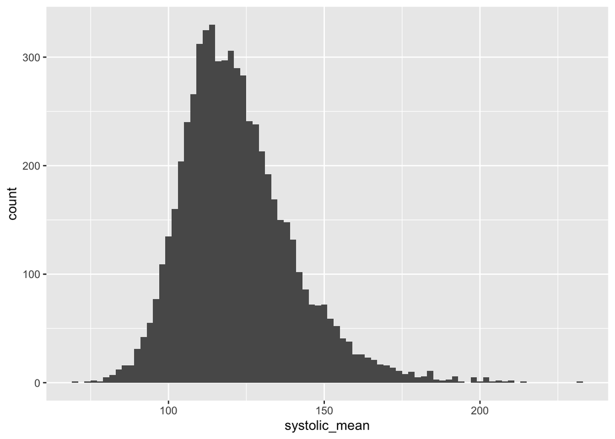

```r
p1 <- ggplot(adult_bp, aes(x = systolic_mean)) +
  geom_histogram(binwidth = 2)

p1
```

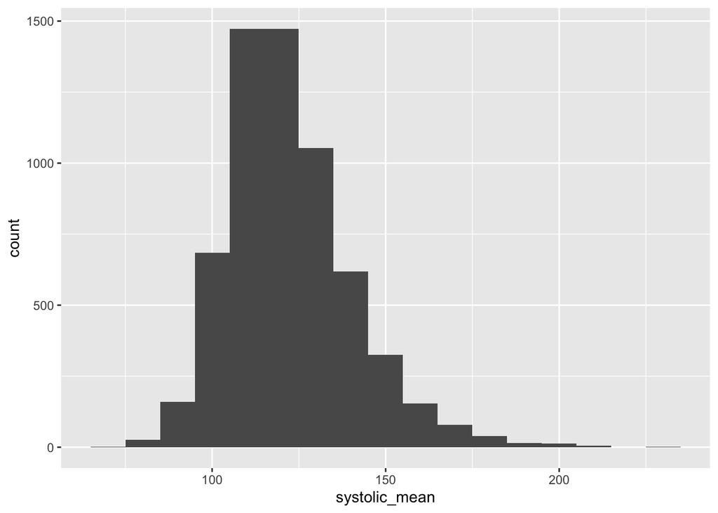

```r
p2 <- ggplot(adult_bp, aes(x = systolic_mean)) +
  geom_histogram(binwidth = 10)

p2
```

The smaller bin width shows more detail. The larger bin width smooths over more of the small variation.

# Density Plot

A density plot shows a smoothed distribution.

The y-axis is density, not number of participants. The total area under the curve is scaled to 1.

Because density plots are smoothed, they can suggest more certainty or structure than the raw data support. Use them as a way to inspect shape, not as proof that every bump is meaningful.

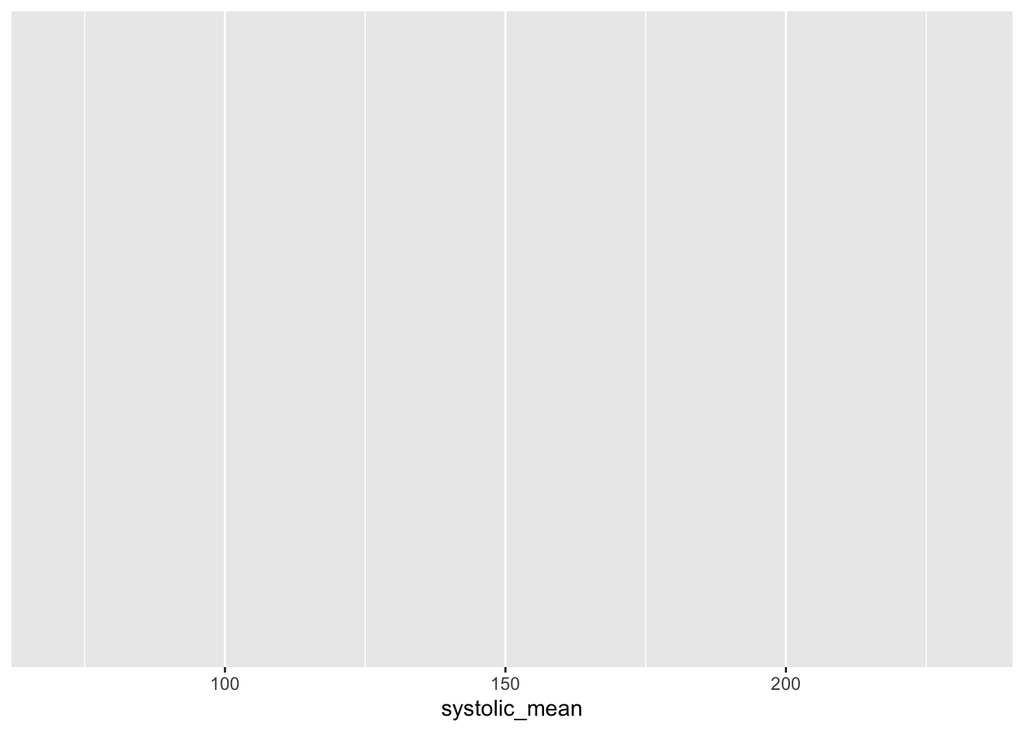

```r
p1 <- ggplot(adult_bp, aes(x = systolic_mean))

p1
```

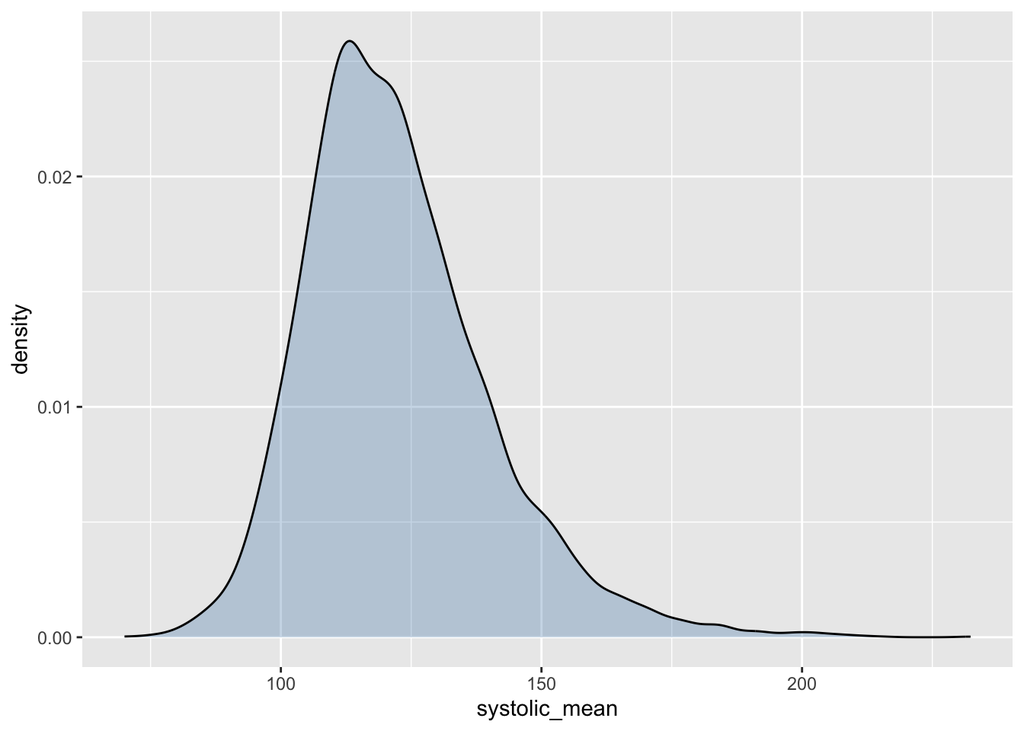

```r
p2 <- p1 +
  geom_density(fill = "steelblue", alpha = 0.3)

p2
```

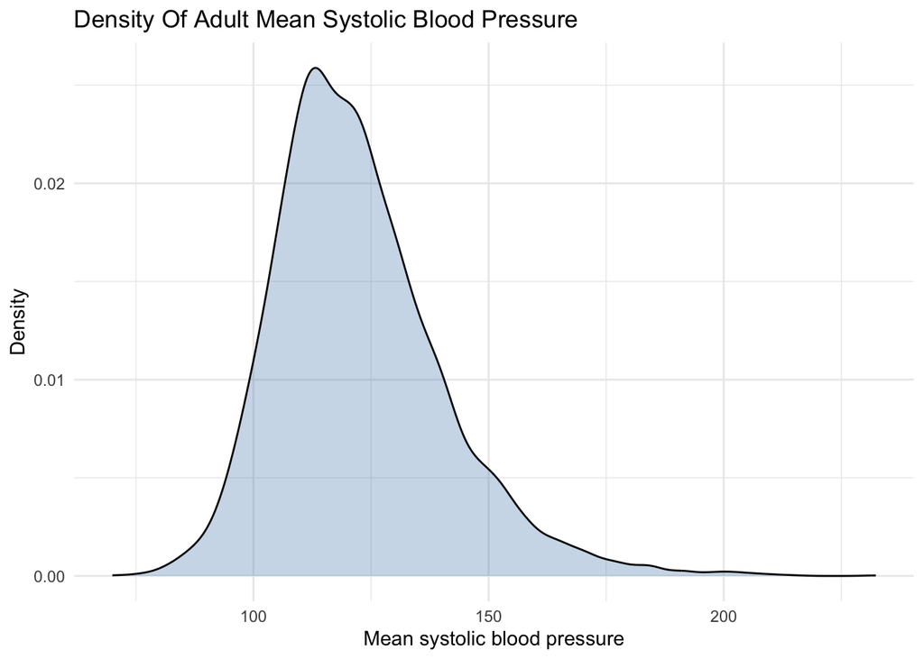

```r
p3 <- p2 +
  labs(
    title = "Density Of Adult Mean Systolic Blood Pressure",
    x = "Mean systolic blood pressure",
    y = "Density"
  ) +
  theme_minimal()

p3
```

# Takeaways

- `filter()` and `select()` prepare the data for the question.
- `summarize()` aggregates many values into summary statistics.
- Histograms are good for count-based distribution questions.
- Bin width is a choice that affects what patterns are visible.
- Density plots emphasize smoothed shape rather than counts.
- Smoothed density can mislead with small samples, bounded variables, or overly detailed interpretations.
- Always connect distribution shape to the unit of observation and the analytic question.